# LISTA DE EXERCICIO 06

# Variáveis aleatórias multidimensionais

Aluno: MARCEL DANTAS DE QUINTELA

## Questão 1

Duas roletas idênticas, que podem resultar nos números 1, 2 ou 3 com igual probabilidade, serão colocadas para rodar simultaneamente. Nesse contexto, defina as seguintes variáveis: $X$: menor número observado entre os resultados das duas roletas, $Y$: maior número observado entre os resultados das duas roletas.

1. Obtenha a função de probabilidade conjunta de X e Y com suas funções de probabilidades marginais.
2. Calcule o valor esperado e variância de $Y-X$.
3. Calcule a covariância entre X e Y.
4. X e Y são variáveis independentes? Justique sua resposta.

### Respostas - Questão 1

> Os possíveis resultados das roletas são os seguintes:

> $(1,1) (1,2) (1,3) (2,1) (2,2) (2,3) (3,1) (3,2) (3,3)$

### **Letra** **a.**

Construindo a matriz de possiveis resultados: Como X é o menor e Y o maior número, observados nos resultados das roletas então, onde $X>Y$ será 0(zero).  
As demais células são preencidas com as quantidades ocorridas de menor e maior valor entre os resultados.

| **X / Y** | **1** | **2** | **3** | **Sum(Y)** |
| --- | --- | --- | --- | --- |
| **1** | 1 | 2 | 2 | *5* |
| **2** | 0 | 1 | 2 | *3* |
| **3** | 0 | 0 | 1 | *1* |
| **Sum(X)** | *1* | *3* | *5* | *9* |

```r
a<-matrix(c(1,0,0,2,1,0,2,2,1),ncol=3)
a
```

```
##      [,1] [,2] [,3]
## [1,]    1    2    2
## [2,]    0    1    2
## [3,]    0    0    1
```

```r
p<- prop.table(a)               # Matrix de probabilidades
MASS::fractions(p)              # Formato de fração
```

```
##      [,1] [,2] [,3]
## [1,] 1/9  2/9  2/9
## [2,]   0  1/9  2/9
## [3,]   0    0  1/9
```

```r
sum(p)                          # Somatório tem que ser 1
```

```
## [1] 1
```

```r
MASS::fractions(addmargins(p))  # Apresentação da Matriz de probalidades com as Marginais
```

```
##                 Sum
##     1/9 2/9 2/9 5/9
##       0 1/9 2/9 1/3
##       0   0 1/9 1/9
## Sum 1/9 1/3 5/9   1
```

```r
apply(p,1,sum)                  # Probabilidade Marginal de X
```

```
## [1] 0.5555556 0.3333333 0.1111111
```

```r
apply(p,2,sum)                  # Probabilidade Marginal de Y
```

```
## [1] 0.1111111 0.3333333 0.5555556
```

### **Letra b.**

- Esperça de (Y-X):

  $$E(Y-X)= E(Y)-E(X)$$

  $E(Y)=\sum_{y=1}^3 y \cdot p(y)= 1\cdot \frac{1}{9} +2\cdot \frac{3}{9} +3\cdot \frac{5}{9}=\frac{22}{9}$

  ```r
  MASS::fractions(EY<-(sum(c(1,2,3)*apply(p,2,sum))))
  ```

  ```
  ## [1] 22/9
  ```

  $E(X)=\sum_{x=1}^3 x \cdot p(x)= 1\cdot \frac{5}{9} +2\cdot \frac{3}{9} +3\cdot \frac{1}{9}=\frac{14}{9}$

  ```r
  MASS::fractions(EX<-(sum(c(1,2,3)*apply(p,1,sum))))
  ```

  ```
  ## [1] 14/9
  ```

  $$E(Y-X)=\frac{22-14}{9}=\frac{8}{9}$$

  ```r
  MASS::fractions(sum(c(1,2,3)*apply(p,2,sum))-sum(c(1,2,3)*apply(p,1,sum)))
  ```

  ```
  ## [1] 8/9
  ```

- Variância de (Y-X):

  $$Var(Y-X)= Var(Y)+Var(X)-2Cov(XY)\\
  = [E(Y^2)-E(Y)^2]+[E(X^2)-E(X)^2]-2[E(XY)-E(X)E(Y)]$$

  $E(Y^2)=\sum_{y=1}^3 y^2 \cdot p(y)= 1^2\cdot \frac{1}{9} +2^2\cdot \frac{3}{9} +3^3\cdot \frac{5}{9}=\frac{58}{9}$

  ```r
  MASS::fractions(EY2<-(sum((c(1,2,3)^2)*apply(p,2,sum))))
  ```

  ```
  ## [1] 58/9
  ```

  $E(X^2)=\sum_{x=1}^3 x^2 \cdot p(x)= 1^2\cdot \frac{5}{9} +2^2\cdot \frac{3}{9} +3^2\cdot \frac{1}{9}=\frac{26}{9}$

  ```r
  MASS::fractions(EX2<-(sum((c(1,2,3)^2)*apply(p,1,sum))))
  ```

  ```
  ## [1] 26/9
  ```

  $E(XY)=\sum_{x=1}^3\sum_{y=1}^3 x\cdot y\cdot p(x,y)= 1\cdot 1\cdot \frac{1}{9} +1\cdot 2\cdot \frac{2}{9} +\cdots+3\cdot 3\cdot \frac{1}{9}=\frac{36}{9}$

  ```r
  (EXY<-c(1,2,3)%*% p %*%c(1,2,3))
  ```

  ```
  ##      [,1]
  ## [1,]    4
  ```

  Então:
  $$Var(Y-X)\\
  = [E(Y^2)-E(Y)^2]+[E(X^2)-E(X)^2]-2[E(XY)-E(X)E(Y)]\\
  =\bigg(\frac{58}{9}-\Big( \frac{22}{9}\Big)^2\bigg)+\bigg(\frac{26}{9}-\Big( \frac{14}{9}\Big)^2\bigg)-2\bigg(4-\frac{14}{9}\cdot\frac{22}{9}\bigg)\\
  0.4691358 + 0.4691358-2\times 0.1975309 = 0.5432099$$

  ```r
  (EY2-EY^2)+(EX2-EX^2)-2*(4-EX*EY)
  ```

  ```
  ## [1] 0.5432099
  ```

  ```r
  rm(list = ls())
  ```

### **Letra c.**

- Covariância entre X e Y:

  $$Cov(XY)= E(XY)-E(X)E(Y)$$

  $E(XY)-E(X)E(Y)=\bigg(4-\frac{14}{9}\cdot\frac{22}{9}\bigg)$

  $$Cov(XY)=0.1975309$$

### **Letra d.**

- Tomemos a matriz de proabilidades:

  | **X / Y** | **1** | **2** | **3** | $P(X=x)$ |
  | --- | --- | --- | --- | --- |
  | **1** | 1/9 | 2/9 | 2/9 | *5/9* |
  | **2** | 0 | 1/9 | 2/9 | *3/9* |
  | **3** | 0 | 0 | 1/9 | *1/9* |
  | $P(Y=y)$ | *1/9* | *3/9* | *5/9* | 1 |

  Além da $cov(XY)\neq0$, existem pares como:

  $P(X=2,Y=3)=\frac{2}{9}\neq P(X=2)P(Y=3)=\frac{5}{27}$

  implicando que X e Y *não são Independentes.*

## Questão 2

Um estudo sobre reconhecimento de dígitos de 1 a 5 para classicação, sabe-se que alguns dígitos em geral são mais escritos pelos usuários que outros. Suponha que a probabilidade esperada para os dígitos 1, 2, 3, 4 e 5 é de 0.1, 0.15, 0.05, 0.2 e 0.5, respectivamente.

1. uma amostra aleatória com 100 dígitos, calcule a probabilidade de que 11 dígitos sejam classicados como 1, 12 como 2, 3 como 3, 18 como 4 e 56 como 5. Use um modelo probabilístico no R para este fim.
2. Se o interesse fosse apenas reconhecer se o dígito é 5 ou não, que modelo (com que parâmetros) seria utilizado? Justique sua resposta.

### Respostas - Questão 2

> Sejam as seguintes variáveis aleatórias:
> - $X_1$: nº de digitos reconhecidos como 1;
> - $X_2$: nº de digitos reconhecidos como 2;
> - $X_3$: nº de digitos reconhecidos como 3;
> - $X_4$: nº de digitos reconhecidos como 4; e
> - $X_5$: nº de digitos reconhecidos como 5;

> Onde o vetor aleatório $X=(X_1,X_2,X_3,X_4,X_5)$, segue distribuição multinomial com parâmetros $n=\sum_{i=1}^{5}X_i$ e $\theta=(0.10,0.15,0.05,0.20,0.50)$ e denotado por:

> $$X \sim Multi\Big(n,\theta=(0.10,0.15,0.05,0.20,0.50)\Big)$$

> Com função de probabilidade:

> $$P(X_1=n_1,X_2=n_2,X_3=n_3,X_4=n_4,X_5=n_5)=\\
> \frac{n!}{n_1!\times n_2!\times n_3! \times n_4!\times n_5!}\times(\theta_1)^{n_1}\times(\theta_2)^{n_2}\times(\theta_3)^{n_3}\times(\theta_4)^{n_4}\times(\theta_5)^{n_5}$$

### **Letra a.**

> $P(X_1=11,X_2=12,X_3=3,X_4=18,X_5=56)$, onde: $X \sim Multi\Big(n=100,p=(0.10,0.15,0.05,0.20,0.50)\Big)$

> $P(X_1=11,X_2=12,X_3=3,X_4=18,X_5=56)=\\ =\frac{100!}{11!\times 12!\times 3!\times 18!\times 56!}\times(0.1)^{11}\times(0.15)^{12}\times(0.05)^3\times(0.2)^{18}\times(0.5)^{56}\\ = 0.0001054424$

```r
dmultinom(c(11,12,03,18,56), prob = c(0.1,0.15,0.05,0.20,0.50))
```

```
## [1] 0.0001054424
```

```r
#
```

### **Letra b.**

O medelo que pode descrever o reconhecimento de um determinado dígito ser 5 ou não em $n$ experimentos é descrito por meio de um modelo de Binomial. Onde:

$X_5$ : V.A. Número de vezes em que o digito 5 é reconhecido com $X_5\sim Binomial(n=100,p=0.5)$

Tal modelo justifica-se pelo fato de: $X_1,X_2,X_3,X_4,X_5 \sim Multi(n;\theta_1,\theta_2, \theta_5,\theta_5,\theta_5)$, então:

$X_i \sim Binomial(n, \theta_i)$

logo:

$X_5 \sim Binomial(n, \theta_5)$

Sendo $P(X=56)=0.03895256$

```r
dbinom(56,100,prob=0.5)
```

```
## [1] 0.03895256
```

Alternativamente poderiamos coniderar:

$X_1,X_2 \sim Mult(n=100; \theta_1=0.5, \theta_2=0.5)$

com:

- $X_1$ : Número de vezes em que o digito 5 é reconhecido;
- $X_2$ : Número de vezes em que o digito 5 não é reconhecido.

Assim temos que $P(X_1=56,X_2=44)=0.03895256$

```r
dmultinom(c(56,44), prob = c(0.5,0.5))
```

```
## [1] 0.03895256
```

## Questão 3

Para o exemplo visto em aula do modelo *Poisson-Gama*, rode novamente o código em *R* assumindo os seguintes valores na distribuição Gama *a priori*: $(\alpha,\beta)=(80,4), (\alpha,\beta)=(10,0.5), (\alpha,\beta)=(4,0.2)$. O que podemos concluir a respeito das distribuição a priori, função de verossimilhança e distribuição a posteriori em cada caso? Note que ao rodar o código para que os gráficos possam ser melhor vistos, será necessário mudar a escala dentro do “curve” no comando “ylim”, basta trocar o valor 0.13 por outro mais adequado.

### Respostas - Questão 3

Sendo observadas que as médias a priori são as mesmas para os 3 cenários, é possível observar que à medida que as estimativas de variâncias a priori vão subindo, o modelo a priori vai perdendo seu poder informativo.

Levando a entender que quanto maior a variabilidade no modelo gama assumido a priori maior a tendência do modelo gama a posteriori se aproximar da verossimilhança, tendo em vista que sobredispersão existente $f_{X|Y=y}\to y\sim Poisson(\lambda=13)$ é tratada pela marginal X contida na definição da posteriori.

- $Gama(\alpha= 80,\beta=4)$

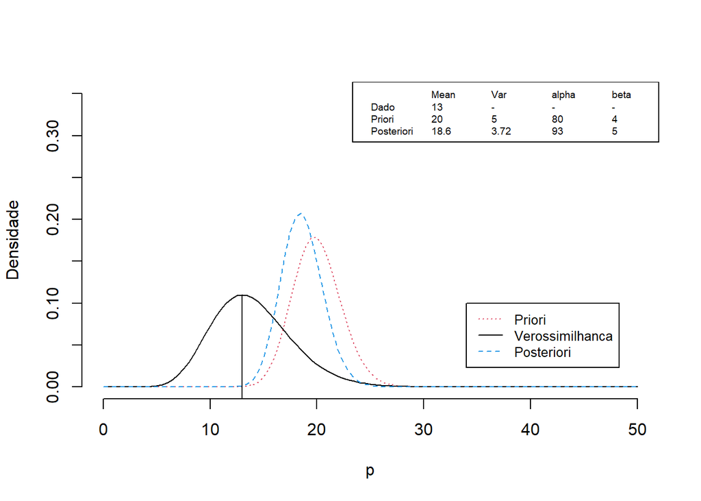

- $Gama(\alpha= 10,\beta=0.5)$

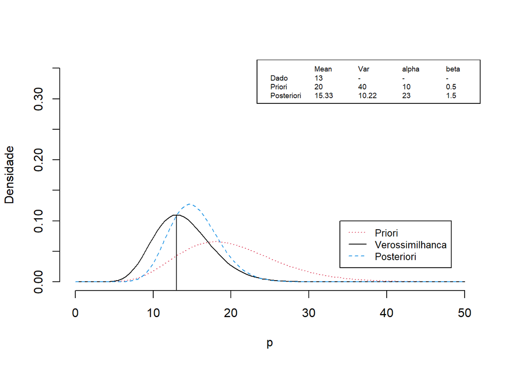

- $Gama(\alpha= 4,\beta=0.2)$

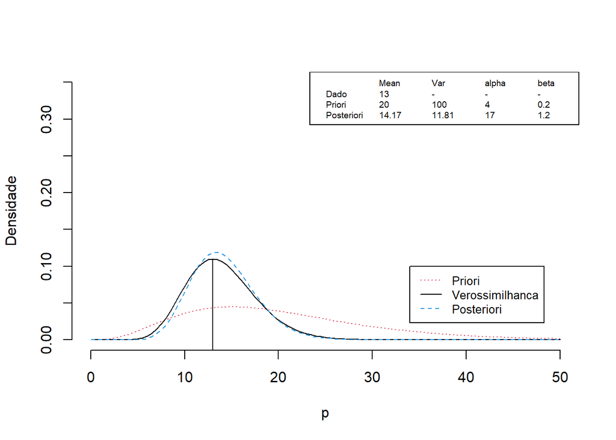